# Innlevering uke 5, BIN210

## 5.5 Lokale sammenstillinger

Resultater for sammenstilling mellom menneske og zebrafisk proteinsekvenser:

- Sequence identity: 38.7 %
- Sequence similarity: 55.2 %
- Gaps: 8.8 %

Resultater for sammenstilling mellom menneske og zebrafisk DNA-sekvenser: - Sequence identity: 51.4 % - Sequence similarity: 51.4 % - Gaps: 31.2 %

Resultatene for de lokale sammenstillingene er noe høyere enn for de globale sammenstillingene. Dette skyldes at lokale sammenstillinger fokuserer på mindre deler av sekvensene, og dermed er mer sannsynlig å finne identiske eller lignende regioner.

## 5.6 Oppsummering

```r
# Tabell over tid siden felles opphav og sammenstillinger for DNA og protein
head(species_tbl)
```

```
##       Species Million_years Seq_identity Seq_similarity Gaps    Type
## 1  Chimpanzee           6.4         99.1           99.1  0.0     DNA
## 2 Giant panda          94.0         84.8           84.8  1.1     DNA
## 3   Zebrafish         429.0         50.4           50.4 32.7     DNA
## 4  Chimpanzee           6.4         98.8           99.1  0.0 Protein
## 5 Giant panda          94.0         79.7           86.8  0.7 Protein
## 6   Zebrafish         429.0         37.8           54.7 10.3 Protein
```

**Prøv å lage en figur som viser resultatene, f.eks. ved å plotte tid siden siste felles opphav på x-aksen og de tre målene (identity, similarity og gaps) på y-aksen farget etter om det er DNA eller protein.**

```r
seq_id <- ggplot(species_tbl) +
          geom_line(aes(x = Million_years, y = Seq_identity, color = Type))
          labs(title = "Sammenstillinger for DNA og protein", x = "Millioner aar siden felles opphav",
          y = "Sequence identity (%)", color = "Type") +
          theme_minimal()
```

```r
seq_sim <- ggplot(species_tbl) +
           geom_line(aes(x = Million_years, y = Seq_similarity, color = Type))
           labs(title = "Sammenstillinger for DNA og protein", x = "Millioner aar siden felles opphav",
           y = "Sequence similarity (%)", color = "Type") +
           theme_minimal()
```

```r
gaps <-    ggplot(species_tbl) +
           geom_line(aes(x = Million_years, y = Gaps, color = Type))
           labs(title = "Sammenstillinger for DNA og protein", x = "Millioner aar siden felles opphav",
           y = "Gaps (%)", color = "Type") +
           theme_minimal()
```

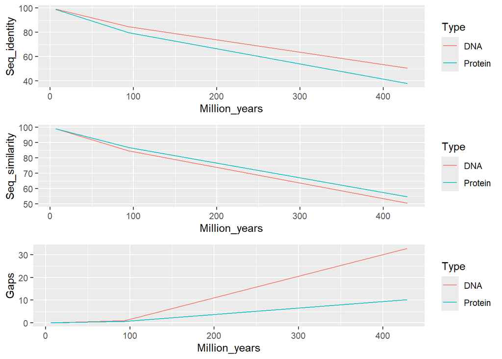

```r
grid.arrange(seq_id, seq_sim, gaps, ncol = 1)
```

Vi ser på plottet over at sekvensidentiteten og likheten går ned med tiden, mens gapene øker. Dette er forventet, da artene har hatt mer tid til å divergere fra hverandre.

# 6 R-lab

## 6.2 Matriser er ikke tabeller

```r
data(BLOSUM45)
data(BLOSUM50)
data(BLOSUM62)
data(BLOSUM80)
data(BLOSUM100)
```

```r
knavn <- colnames(BLOSUM62)
print(knavn)
```

```
##  [1] "A" "R" "N" "D" "C" "Q" "E" "G" "H" "I" "L" "K" "M" "F" "P" "S" "T" "W" "Y"
## [20] "V" "B" "J" "Z" "X" "*"
```

De første 20 bokstavene er one-letter koden for aminosyrer. De fem neste er:

- B: Betegner Asparagin eller Aspartat. Benyttes når det ikke er mulig å skille disse to aminosyrene (lignende struktur).
- J: Betegner Leucin eller Isoleucin, samme begrunnelse som B
- Z: Betegner Glutamin eller Glutamat, samme begrunnelse som B
- X: Ukjent eller uspesifisert aminosyre. Benyttes når det ikke er mulig å identifisere aminosyren.
- *: Representerer en STOPP-kodon i sekvensen (slutten på en polypeptidkjede)

## 6.4 Operasjoner på vektorer og matriser

```r
length(BLOSUM100)
```

```
## [1] 576
```

Funksjonen length angir antall elementer i matrisen. I denne matrisen er det 24*24 elementer = 576.

## 6.5 Oppgaver: BLOSUM-matrisene

```r
# Henter ut de første 20 radene og kolonnene i hver matrise

B45 <- BLOSUM45[1:20,1:20]
B50 <- BLOSUM50[1:20,1:20]
B62 <- BLOSUM62[1:20,1:20]
B80 <- BLOSUM80[1:20,1:20]
B100 <- BLOSUM100[1:20,1:20]
```

```r
# Kopier diagonaleleqmentene i hver matrise til en vektor

diag.45 <- diag(B45)
diag.50 <- diag(B50)
diag.62 <- diag(B62)
diag.80 <- diag(B80)
diag.100 <- diag(B100)
```

```r
# Beregn gjennomsnittet av diagonalen i hver matrise

diag.mean <- c(mean(diag.45), mean(diag.50), mean(diag.62), mean(diag.80), mean(diag.100))
names.diag <- c("BLOSUM45", "BLOSUM50", "BLOSUM62", "BLOSUM80", "BLOSUM100")
```

```r
# Beregn gjennomsnittet av alle elementer som ikke er på diagonalen

not.diag.mean.45 <- (sum(B45) - sum(diag.45)) / (length(B45) - length(diag.45))
not.diag.mean.50 <- (sum(B50) - sum(diag.50)) / (length(B50) - length(diag.50))
not.diag.mean.62 <- (sum(B62) - sum(diag.62)) / (length(B62) - length(diag.62))
not.diag.mean.80 <- (sum(B80) - sum(diag.80)) / (length(B80) - length(diag.80))
not.diag.mean.100 <- (sum(B100) - sum(diag.100)) / (length(B100) - length(diag.100))

# lagre gjennomsnittene i en vektor

not.diag.mean <- c(not.diag.mean.45, not.diag.mean.50, not.diag.mean.62, not.diag.mean.80, not.diag.mean.100)
```

```r
# Lag en tabell
BLOSUM.tbl <- data.frame(names.diag, diag.mean, not.diag.mean)
colnames(BLOSUM.tbl) <- c("names", "match_score", "mismatch_score")
print(BLOSUM.tbl)
```

```
##       names match_score mismatch_score
## 1  BLOSUM45        7.05      -1.336842
## 2  BLOSUM50        7.50      -1.610526
## 3  BLOSUM62        5.80      -1.426316
## 4  BLOSUM80        6.20      -2.005263
## 5 BLOSUM100       10.60      -4.142105
```

```r
# Lag en ny kolonne 'net_score', match_score + mismatch_score
net_score <- diag.mean + not.diag.mean
BLOSUM.tbl <- cbind(BLOSUM.tbl, net_score)
```

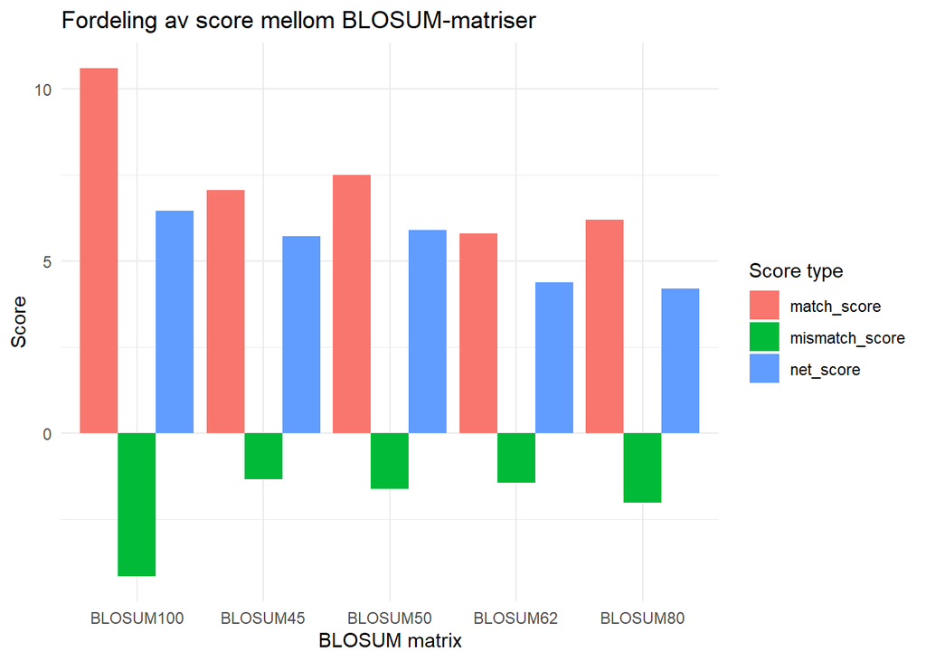

```r
# Lag et stolpediagram som viser match_score, mismatch_score og net_score for hver BLOSUM-matrise

BLOSUM_long <- BLOSUM.tbl %>%
  pivot_longer(cols = c("match_score", "mismatch_score", "net_score"), names_to = "score_type", values_to = "score")


ggplot(BLOSUM_long, aes(x = names, y = score, fill = score_type)) +
  geom_bar(stat = "identity", position = "dodge") +
  labs(title = "Fordeling av score mellom BLOSUM-matriser", x = "BLOSUM matrix", y = "Score", fill = 'Score type') +
  theme_minimal()
```

**Hvordan varierer match_score, mismatch_score og net_score mellom de ulike BLOSUM-matrisene?**

- Match_score er høyest i BLOSUM100, mens mismatch_score er høyest i BLOSUM45. Dette er forventet, da BLOSUM100 er basert på høyt beslektede sekvenser, mens BLOSUM45 er basert på mer divergente sekvenser. Høyt beslektede sekvenser vil ha flere identiske aminosyrer, og dermed høyere match_score.
- Net-scoren er også høyest i BLOSUM100, noe som indikerer like sekvenser.
- BLOSUM-matriser benyttes til å forutsi hvor sannsynlig det der at to aminosyrer er byttet ut med hverandre i en evolusjonær sammenheng. En høy net score kan indikere felles opprinnelse.